# InVivoStat Dose-response Analysis

## Response and dose variables

The Resp 1 response is currently being analysed by the Dose-response and Non-Linear Regression Analysis module.

The dose variable (Dose1) has been log10 transformed prior to analysis.

## Scatterplot of observed data including the predicted fit

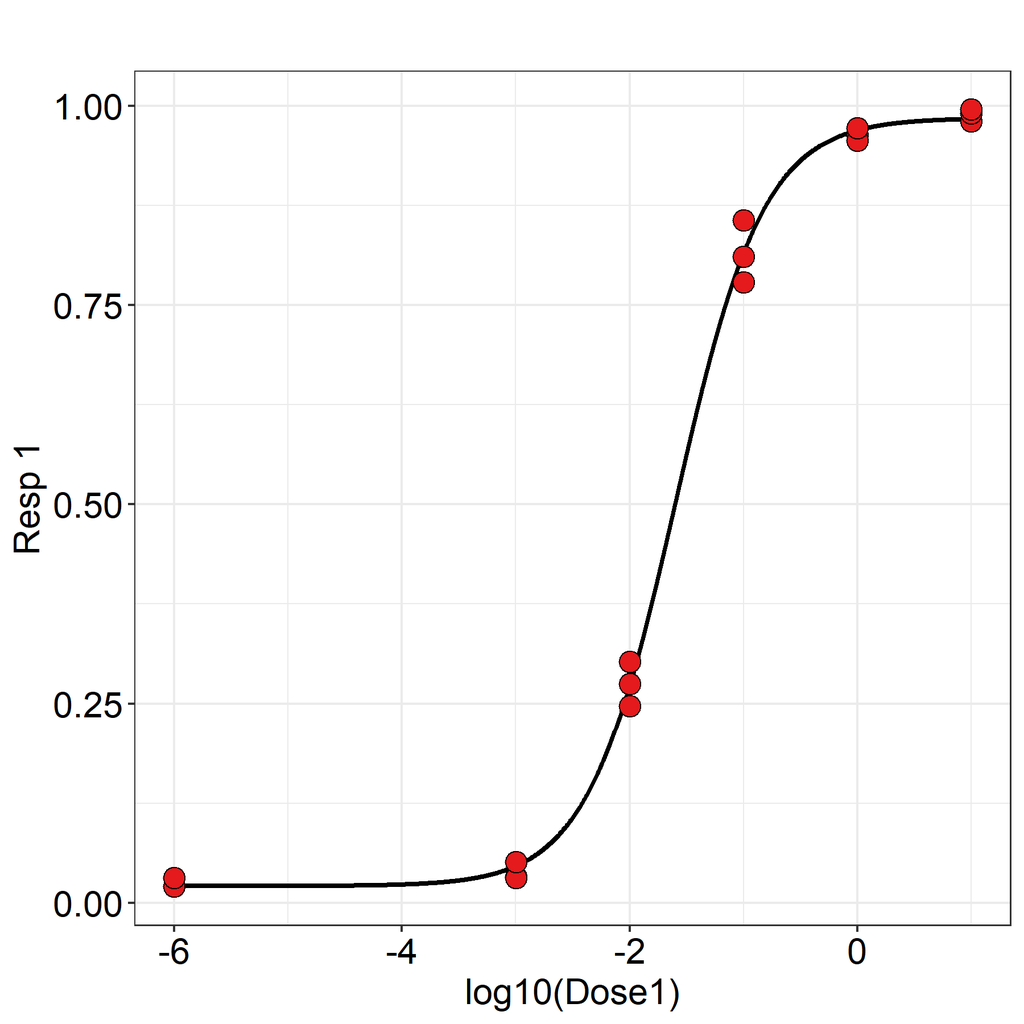

## Table of curve parameters and summary statistics

| Parameter | Estimate | Std error | t-value | p-value |
| --- | --- | --- | --- | --- |
| A | 0.984 | 0.009 | 107.51 | < 0.0001 |
| B | 1.123 | 0.053 | 21.34 | < 0.0001 |
| C | -1.599 | 0.025 | -63.53 | < 0.0001 |
| D | 0.021 | 0.009 | 2.29 | 0.0381 |

## Back-transformed ED50 estimate with 95% confidence intervals

|  | ED50 | Lower 95% CI | Upper 95% CI |
| --- | --- | --- | --- |
| Estimate | 0.025 | 0.022 | 0.029 |

## Description of the analysis results

The data was analysed using non-linear regression. The estimate of the minimum of the curve is 0.021. The estimate of the maximum of the curve is 0.984. The estimate of the slope coefficient of the curve is 1.123. The estimate of the logED50 of the curve is -1.599. The back-transformed estimate of the ED50 of the curve is 0.025.

For more information on the theoretical approaches that are implemented within this module, see Bate and Clark (2014).

## Scatterplot of responses and quality control (QC) samples

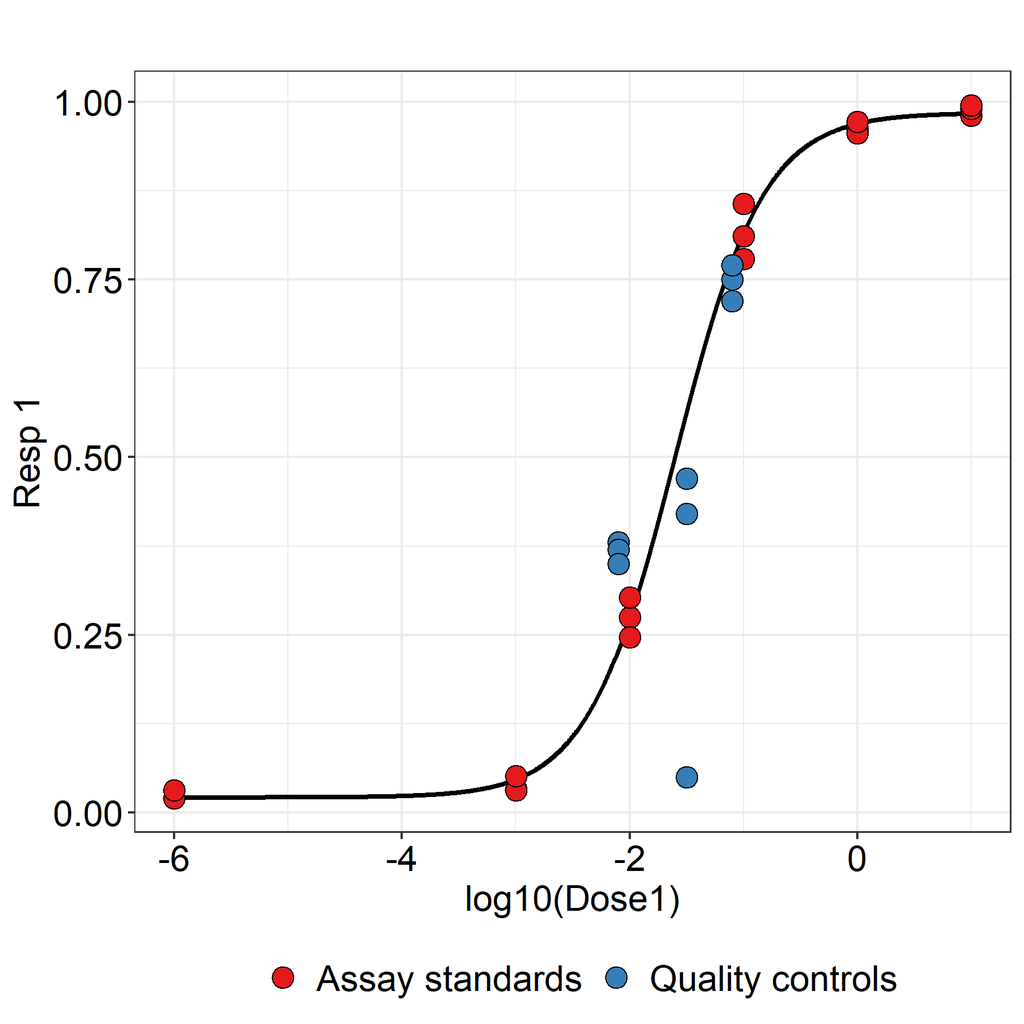

## Table of QC summary statistics

| QC ID number | True QC mean | Back-calculated QC mean | Std dev of back-calculated QC mean | No. of back-calculated QCs | Relative error (%) | Coefficient of variation (%) |
| --- | --- | --- | --- | --- | --- | --- |
| 1 | 0.008 | 0.015 | 0.001 | 3 | 88.99 | 4.06 |
| 2 | 0.032 | 0.008 | 0.022 | 3 | -75.41 | 279.20 |
| 3 | 0.079 | 0.068 | 0.006 | 3 | -14.10 | 8.26 |

Note: The relative error (%) and coefficient of variation (%) for an individual QC are only reliable statistics if all the QCs can be back-calculated.

## Back-calculated sample responses

| Sample ID number | Sample response | Back-calculated response |
| --- | --- | --- |
| 1 | 0.2 | 0.007 |
| 2 | 0.6 | 0.036 |
| 3 | 0.4 | 0.017 |
| 4 | 0.2 | 0.007 |
| 5 | 0.5435 | 0.029 |
| 6 | 0.675543 | 0.049 |
| 7 | 0.8765 | 0.159 |
| 8 | 0.232 | 0.008 |
| 9 | 0.99 | NaN |
| 10 | 0.02 | NaN |
| 11 | 0.01 | NaN |

## References

When referring to InVivoStat, please cite 'InVivoStat, version 5.2.0'.

Bate, S.T. and Clark, R.A. (2014). The Design and Statistical Analysis of Animal Experiments. Cambridge University Press.